# presentation_sel_asl

**Proto-role encoding in a narrative production task:**

**A comparison of autistic and neurotypical children**

Zuriñe Ábalos

[figure not shown]

, Marta Sánchez-López

[figure not shown]

University of the Basque Country (UPV/EHU)

[figure not shown]

[figure not shown]

[figure not shown]

[figure not shown]

[figure not shown]

# Index

- Introduction
- The present study
- Methods
- Analysis
- Discussion
- Conclusion
- References

# Introduction

Introduction: Event roles

Event roles

**The girl** hits **the ball**.

⇩

Agent

⇩

Patient

Introduction: Event roles

One-word and two-word children can distinguish between agents and patients in processing event tasks, showing an early emerging bias toward agents.

Robertson & Suci (1980)

Infants between 14 and 24 months old are able to notice when an agent changes from being the agent to being the patient of the event.

Gertner et al. (2006), Golinkoff (1975)

Introduction: Event roles

Production data also reveal sensitivity to the agent and patient roles: 2-year-old children reliably assign appropriate agent and patient roles when describing events.

Angiolillo & Goldin-Meadow (1982), Bloom (1970), Brown (1973)

Introduction: Event roles

Neurotypical adults also extract event role information rapidly and use it to make predictions during sentence processing.

Kim et al. (2016)

Agents and patients are two salient categories that are processed quickly and robustly, being agents more salient than patients.

Hafri et al. (2013; 2018), Ünal et al. (2024)

Introduction: Event roles

Proto-role approach is particularly consistent with previous empirical evidence on event roles.

- **Proto-agent and proto-patient.**
- **Proto-agent**: causation, volition, sentience, and movement.

Proto-roles are non-discrete categories.

Dowty (1991)

Introduction

Strong evidence of distinct processing mechanisms and production patterns associated with agents and patients in typical development.

What about **atypical** development?

Introduction: Autism

Neurodevelopmental condition characterized by difficulties in social communication and social interaction.

American Psychiatric Association (2013)

Huge variability in terms of structural language (vocabulary, grammar), but persistent pragmatic difficulties (i.e., difficulties in using language appropriately to communicate with others).

Introduction: Autism

Narratives

- Ecologically valid
- Mirrors the demands of everyday communication
- Important differences between autistic and neurotypical children’s narratives

Baixauli et al. (2016)

Introduction: Autism

Constructing coherent stories → challenging for autistic individuals

Baixauli et al. (2016)

- More irrelevant details

Losh & Capps (2003), Peristeri et al. (2025)

- Fewer key story elements or characters

Belenger et al. (2025), Peristeri et al. (2025)

- Fewer causal connections

Ábalos et al. (2025), Diehl et al. (2006), Kelley et al. (2006), Losh & Capps (2003)

Introduction: Autism

Theory of Mind

Baron-Cohen et al. (1985), Capps et al. (2000), Colle et al. (2008)

Kenan et al. (2019), Tager-Flusberg & Sullivan (1995)

Local Processing

Frith & Happé (1994), Happé & Frith (2006), Kenan et al. (2019)

Executive Functions

Demetriou et al. (2018), Demetriou et al. (2019), Greco et al. (2023), Scionti et al. (2023)

Scionti et al. (2023)

# The present study

Do autistic and neurotypical children differ in the number of agents and patients they include in their narratives?

Do group differences in the production of agents stem from specific proto-agent entailments?

# Methods

Methods: Participants

[output not shown]

Methods: Data collection

[figure not shown]

[figure not shown]

Methods: Coding

| Category | Example |
| --- | --- |
| Proto-patient | **The boy** fell. |
| Sentience | **The boy** saw the frog. |
| Causation | **The deer** caught him by accident. |
| Movement | **The boy** ran. |
| Volition + Sentience | **The boy** looked for the frog. |
| Volition + Movement | **The dog** ran from the bees. |
| Causation + Movement | **The deer** took them to the lake by accident. |
| Sentience + Volition + Causation | **The boy** told off the dog. |
| Sentience + Volition + Causation + Movement | **The boy** opened the window. |

Methods: Coding

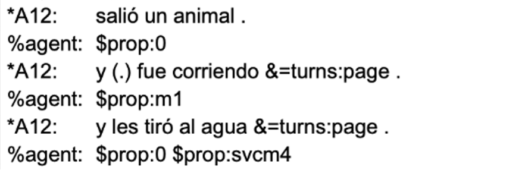

# Analysis

**Analysis**

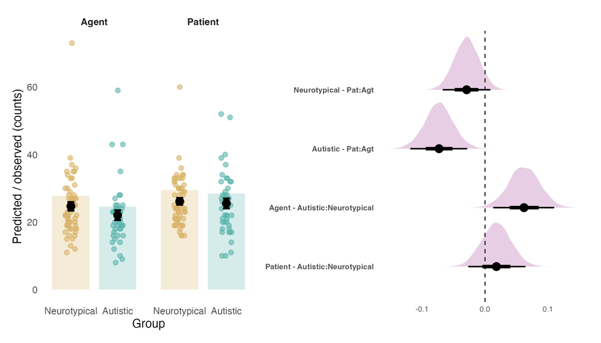

**Analysis**

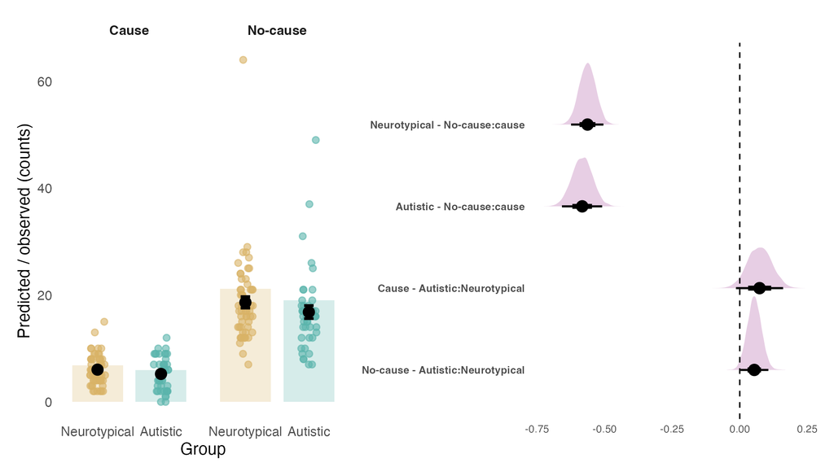

**Analysis**

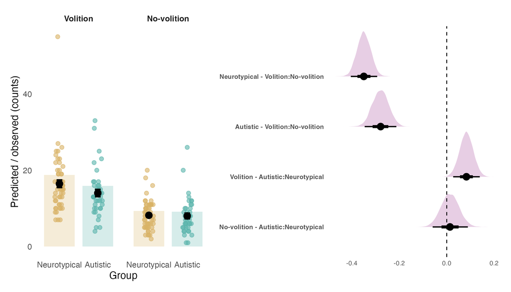

**Analysis**

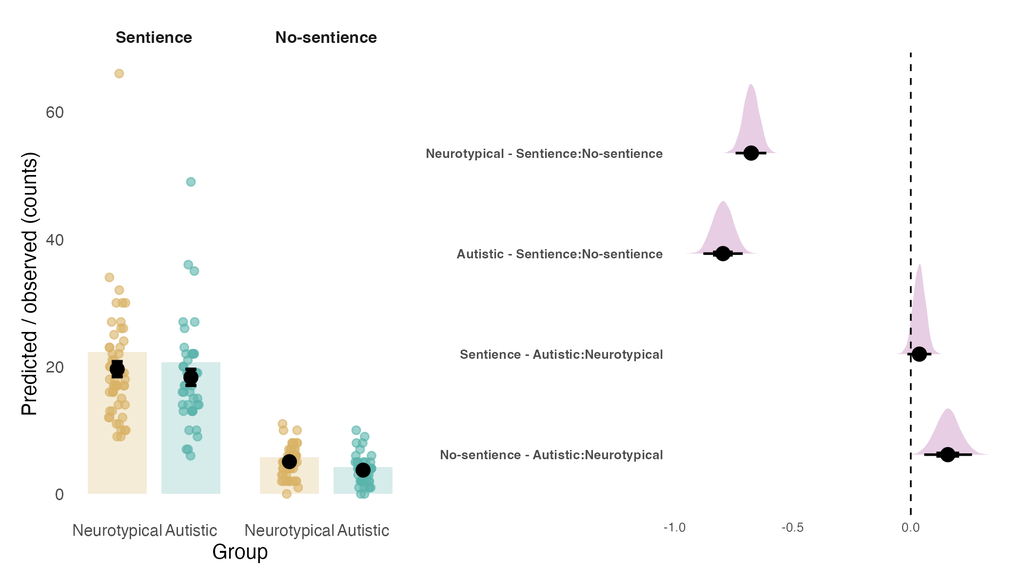

**Analysis**

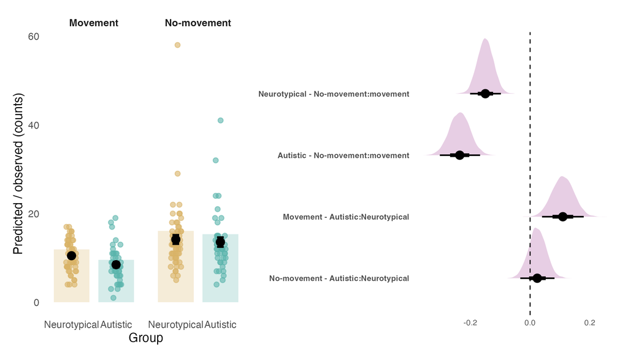

# Discussion

Discussion

1. Do autistic and neurotypical children differ in the number of agents and patients they include in their narratives?
- We found that neurotypical children produced more agents than autistic children.
- No differences in the production of patients.

Discussion

2. Do group differences in the production of agents stem from specific proto-agent entailments?
- Differences in the production of agents with the entailments of volition and movement.
- Autistic children produced fewer agents with the volition entailment. It entails reasoning about the mental states and goals of the characters (ToM).

Discussion

Do group differences in the production of agents stem from specific proto-agent entailments?

- Autistic children produced fewer agents with the movement entailment. Group differences emerged only when followed by Purpose clause (e.g., *the dog jumped to break the jar*).

# Conclusion

Autistic and neurotypical children rely on different mechanisms to codify event roles.

The processing of intentionality marks production differences of agents between autistic and neurotypical children.

¡Muchas gracias!

[figure not shown]

[figure not shown]

[figure not shown]

[figure not shown]

[figure not shown]

Ábalos, Z., Vicente, A., Vicente, B., & Castroviejo, E. (2025). Comparing the narrative coherence of Spanish-speaking autistic and typically developing children: Focus on causal rhetorical relations. *Applied Psycholinguistics*, *46*, e15. https://doi.org/10.1017/S014271642500013X

American Psychiatric Association. (2013). *Diagnostic and Statistical Manual of Mental Disorders* (Fifth Edition). American Psychiatric Association. https://doi.org/10.1176/appi.books.9780890425596

Angiolillo, C. J., & Goldin-Meadow, S. (1982). Experimental evidence for agent–patient categories in child language. *Journal of Child Language*, *9*(3), 627–643. https://doi.org/10.1017/S0305000900004943

Baixauli, I., Colomer, C., Roselló, B., & Miranda, A. (2016). Narratives of children with high-functioning autism spectrum disorder: A meta-analysis. *Research in Developmental Disabilities*, *59*, 234–254. https://doi.org/10.1016/j.ridd.2016.09.007

Baron-Cohen, S., Leslie, A. M., & Frith, U. (1985). Does the autistic child have a “theory of mind” ? *Cognition*, *21*(1), 37–46. https://doi.org/10.1016/0010-0277(85)90022-8

Belenger, M., Dumont, C., Geelhand, P., & Kissine, M. (2025). Investigating sex differences in narrative production of autistic pre-adolescents and adolescents. *Research in Autism*, *124*, 202589. https://doi.org/10.1016/j.reia.2025.202589

Bloom, L. (1970). *Language development: Form and function in emerging grammars*. MIT Press.

Brown, R. (1973). *A first language: The early stages*. Harvard University Press. https://doi.org/10.4159/harvard.9780674732469

Capps, L., Losh, M., & Thurber, C. (2000). “The Frog Ate the Bug and Made his Mouth Sad”: Narrative Competence in Children with Autism. *Journal of Abnormal Child Psychology*, *28*(2), 193–204. https://doi.org/10.1023/A:1005126915631

Colle, L., Baron-Cohen, S., Wheelwright, S., & Van Der Lely, H. K. J. (2008). Narrative discourse in adults with high-functioning autism or asperger syndrome. *Journal of Autism and Developmental Disorders*, *38*(1), 28–40. https://doi.org/10.1007/s10803-007-0357-5

Demetriou, E. A., DeMayo, M. M., & Guastella, A. J. (2019). Executive Function in Autism Spectrum Disorder: History, Theoretical Models, Empirical Findings, and Potential as an Endophenotype. *Frontiers in Psychiatry*, *10*, 753. https://doi.org/10.3389/fpsyt.2019.00753

Demetriou, E. A., Lampit, A., Quintana, D. S., Naismith, S. L., Song, Y. J. C., Pye, J. E., Hickie, I., & Guastella, A. J. (2018). Autism spectrum disorders: A meta-analysis of executive function. *Molecular Psychiatry*, *23*(5), 1198–1204. https://doi.org/10.1038/mp.2017.75

Diehl, J. J., Bennetto, L., & Young, E. C. (2006). Story Recall and Narrative Coherence of High-Functioning Children with Autism Spectrum Disorders. *Journal of Abnormal Child Psychology*, *34*(1), 83–98. https://doi.org/10.1007/s10802-005-9003-x

Dowty, D. (1991). Thematic proto-roles and argument selection. *Language*, *67*(3), 547–619. https://doi.org/10.1353/lan.1991.0021

Frith, U., & Happé, F. (1994). Autism: Beyond “theory of mind.” *Cognition*, *50*, 115–132.

Gertner, Y., Fisher, C., & Eisengart, J. (2006). Learning words and rules: Abstract knowledge of word order in early sentence comprehension. *Psychological Science*, *17*(8), 684–691. https://doi.org/10.1111/j.1467-9280.2006.01767.x

Golinkoff, R. M. (1975). *Semantic development in infants: The concepts of agent and recipient*. *21*(3), 181–193.

Greco, G., Choi, B., Michel, K., & Faja, S. (2023). Here’s the story: Narrative ability and executive function in autism spectrum disorder. *Research in Autism Spectrum Disorders*, *101*, 102092. https://doi.org/10.1016/j.rasd.2022.102092

Hafri, A., Papafragou, A., & Trueswell, J. C. (2013). Getting the gist of events: Recognition of two-participant actions from brief displays. *Journal of Experimental Psychology: General*, *142*, 880–905. https://doi.org/10.1037/a0030045

Hafri, A., Trueswell, J. C., & Strickland, B. (2018). Encoding of event roles from visual scenes is rapid, spontaneous, and interacts with higher-level visual processing. *Cognition*, *175*, 36–52. https://doi.org/10.1016/j.cognition.2018.02.011

Happé, F., & Frith, U. (2006). The Weak Coherence Account: Detail-focused Cognitive Style in Autism Spectrum Disorders. *Journal of Autism and Developmental Disorders*, *36*(1), 5–25. https://doi.org/10.1007/s10803-005-0039-0

Kelley, E., Paul, J. J., Fein, D., & Naigles, L. R. (2006). Residual Language Deficits in Optimal Outcome Children with a History of Autism. *Journal of Autism and Developmental Disorders*, *36*(6), 807–828. https://doi.org/10.1007/s10803-006-0111-4

Kenan, N., Zachor, D. A., Watson, L. R., & Ben-Itzchak, E. (2019). Semantic-pragmatic impairment in the narratives of children with autism spectrum disorders. *Frontiers in Psychology*, *10*. https://doi.org/10.3389/fpsyg.2019.02756

Kim, A. E., Oines, L. D., & Sikos, L. (2016). Prediction during sentence comprehension is more than a sum of lexical associations: The role of event knowledge. *Language, Cognition and Neuroscience*, *31*(5), 597–601. https://doi.org/10.1080/23273798.2015.1102950

Losh, M., & Capps, L. (2003). Narrative Ability in High-Functioning Children with Autism or Asperger’s Syndrome. *Journal of Autism and Developmental Disorders*, *33*(3), 239–251. https://doi.org/10.1023/A:1024446215446

Peristeri, E., Drakoulaki, K., Boznou, A., Nerantzini, M., & Varlokosta, S. (2025). Linguistic Markers of Autism Spectrum Disorder in Narrative Production: Evidence From the Monkey Cartoon Storytelling Task of the Autism Diagnostic Observation Schedule. *Autism & Developmental Language Impairments*, *10*, 23969415251331045. https://doi.org/10.1177/23969415251331045

Robertson, S. S., & Suci, G. J. (1980). Event perception by children in the early stages of language production. *Child Development*, *51*(1), 89–96.

Scionti, N., Zampini, L., & Marzocchi, G. M. (2023). The Relationship between Narrative Skills and Executive Functions across Childhood: A Systematic Review and Meta-Analysis. *Children*, *10*(8), 1391. https://doi.org/10.3390/children10081391

Tager-Flusberg, H., & Sullivan, K. (1995). A second look at second-order belief attribution in autism. *Journal of Autism and Developmental Disorders*, *24*(5), 577–586. https://doi.org/10.1007/BF02172139

Ünal, E., Wilson, F., Trueswell, J., & Papafragou, A. (2024). Asymmetries in encoding event roles: Evidence from language and cognition. *Cognition*, *250*, 105868. https://doi.org/10.1016/j.cognition.2024.105868